# Quickstart Guide to ggseqalign

Simeon Lim Rossmann

Norwegian University of Life Sciences (NMBU)

simeon.rossmann@nmbu.no

8 May 2024

#### Abstract

Provides basic instructions to create minimal visualizations of pairwise alignments from various inputs.

#### Package

ggseqalign 0.1.0

# Contents

## 0.1 Introduction

Showing small differences between two long strings, such as DNA or AA sequences is challenging, especially in R. Typically, DNA or AA sequence alignments show all characters in a sequence. The package *ggmsa* does this really well and is compatible with ggplot2. However, this is not viable for sequences over a certain length. Alternatively, top level visualizations may, for example, represent degree of variation over the length in a line plot, making it possible to gauge how strongly sequences differ, but not the quality of the difference. The intention with this package is to provide a way to visualize sequence alignments over the whole length of arbitrarily long sequences without losing the ability to show small differences, see figure 1.

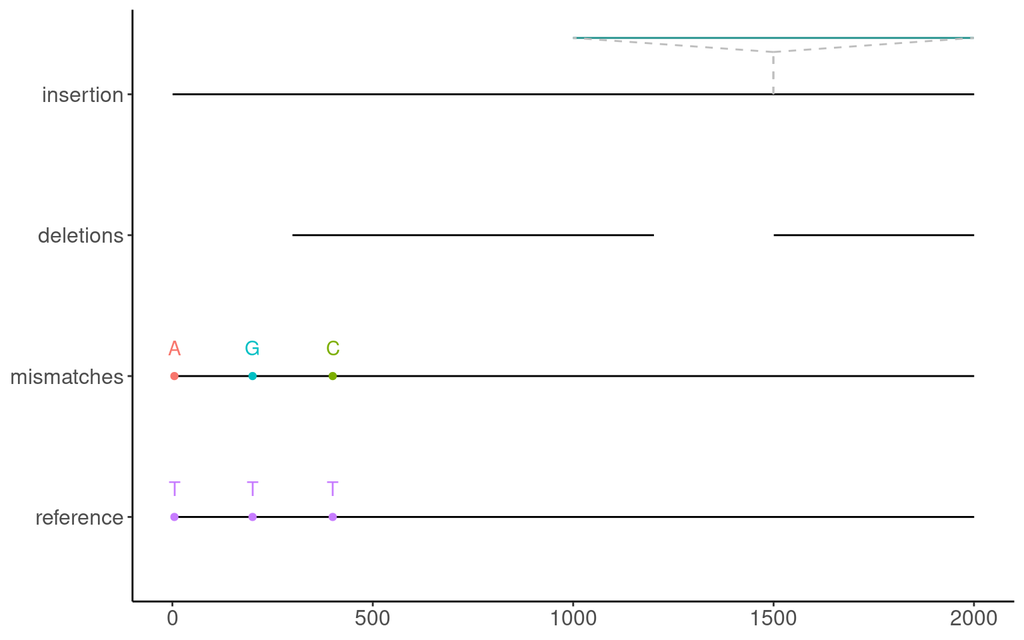

## 0.2 Installation

`ggseqalign` can be installed from it’s original source on GitLab (requires `devtools`)

```r
devtools::install_git("https://gitlab.com/nmbu.no/ipv/lim-rossmann/ggseqalign.git")
```

Once it becomes available on the devel version of Bioconductor, it can be installed with

```r
if (!requireNamespace("BiocManager", quietly=TRUE))
    install.packages("BiocManager")
BiocManager::install("ggseqalign", version = "devel")
```

## 0.3 Basics

This package relies on two core functions, `alignment_table()` and `plot_sequence_alignment()`. The former uses `Biostrings::PairwiseAlignment()` at its core to align one or several query strings to a subject string to parse all information on mismatches, insertions and deletions int a table that is used as the input for plotting with `plot_sequence_alignment()`.

## 0.4 Hide mismatches

The plots that `plot_sequence_alignment()` generates can become hard to read if there are too many differences, see fig. 2. The package allows to hide character mismatches to preserve legibility of structural differences (fig. 3).

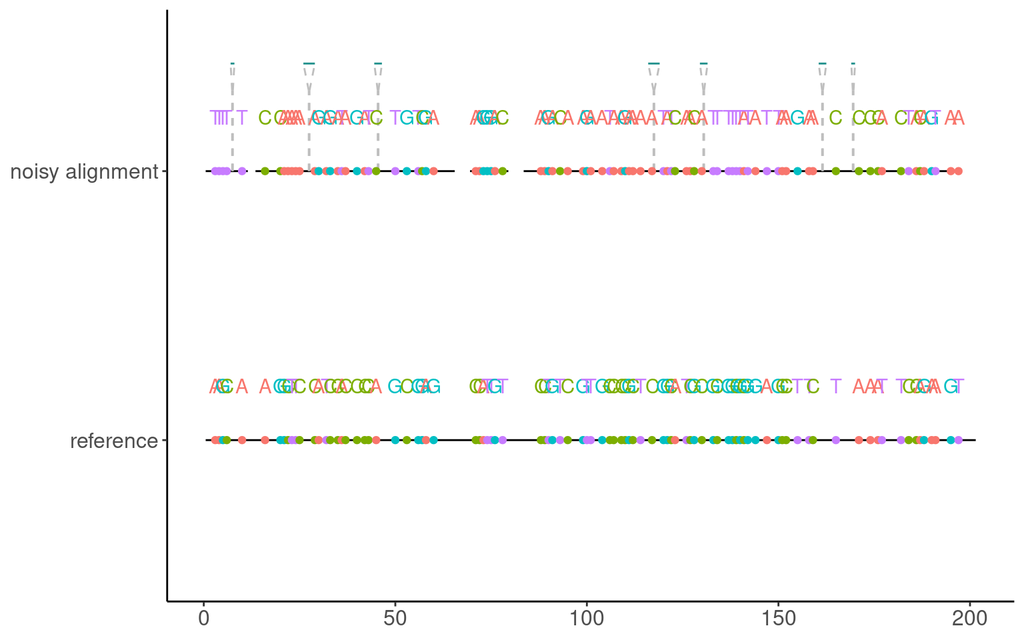

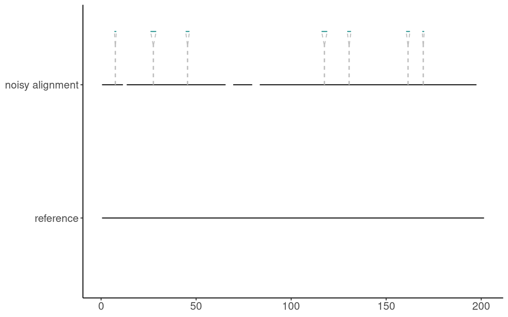

Figure 3: Hiding mismatches  
Hiding character mismatches reduces visual noise if alignments have many character mismatches and preserves structural information.

# 1 Style macros

*BiocStyle* introduces the following macros for referring to *R* packages:

- *IRanges*, for *Bioconductor* software, annotation and experiment data packages,
- *data.table*, for *R* packages available on CRAN,
- *rmarkdown*, for *R* packages available on GitHub,
- *MyPkg*, for *R* packages that are *not* available on *Bioconductor*, CRAN or GitHub.

# 2 Figures

Small and wide figures can be specified by `fig.small` and `fig.wide` code chunk options.

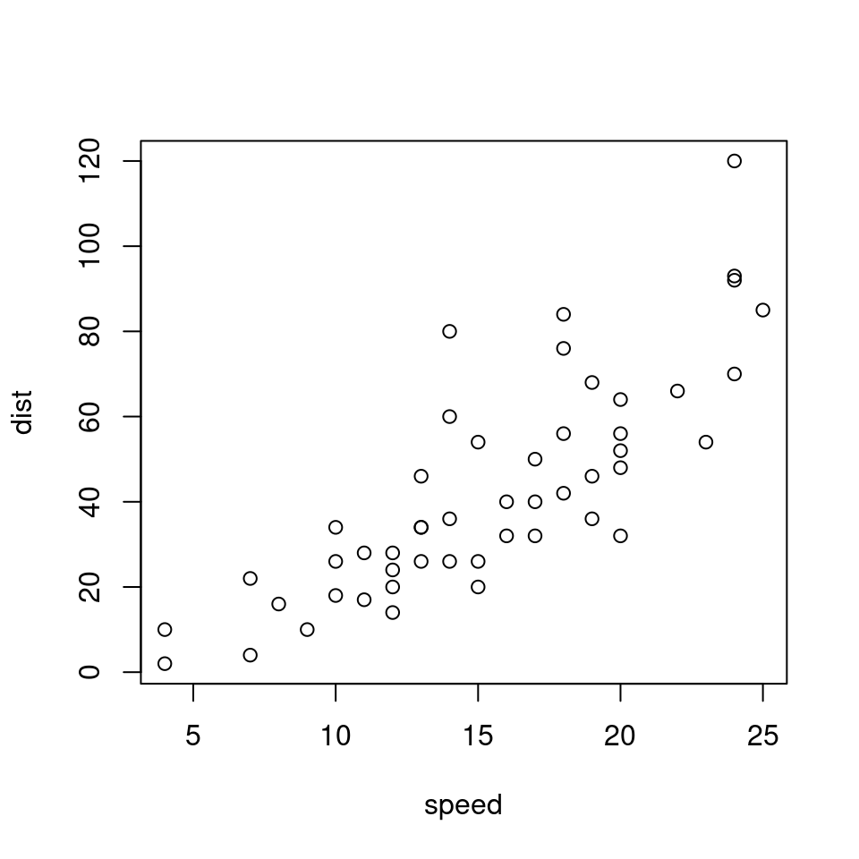

Figure 4: Small figure  
A plot produced by a code chunk with option `fig.small = TRUE`.

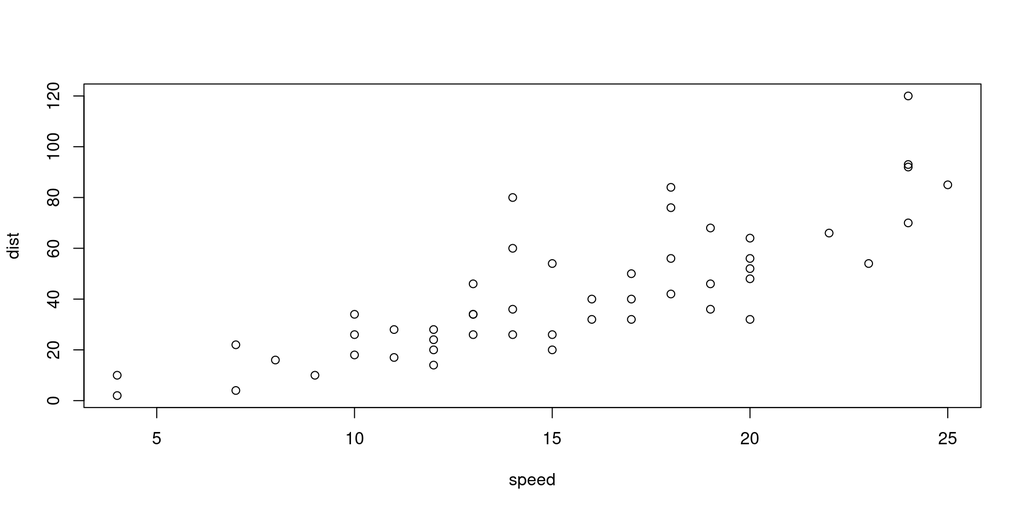

Figure 5: Wide figure  
A plot produced by a code chunk with option `fig.wide = TRUE`.

# 3 Equations

To number and reference equations, put them in equation environments and assign labels to them, see Equation (1).

$$\begin{equation}
f\left(k\right) = \binom{n}{k} p^k\left(1-p\right)^{n-k}
\tag{1}
\end{equation}$$

# 4 Tables

Like figures, tables with captions will also be numbered and can be referenced, see Table 1.

Table 1: A simple table With caption.

| Fruit | Price |
| --- | --- |
| bananas | 1.2 |
| apples | 1.0 |
| oranges | 2.5 |

# 5 Cross-references

Apart from referencing figures (Section 2), tables (Section 4), and equations (Section 3), you can also use the same syntax to refer to sections by their default labels generated by pandoc.

# 6 Side notes

Footnotes are displayed as side notes on the right margin, which has the advantage that they appear close to the place where they are defined.

this is a side note entered as a footnote